# ISYE 6414 Homework 4 Peer Assessment Solutions

ISYE 6414 Instructor

Fall 2022

# Peer Grader Guidance

Please review the student expectations for peer review grading and peer review comments. Overall, we ask that you score with accuracy. When grading your peers, you will not only learn how to improve your future homework submissions but you will also gain deeper understanding of the concepts in the assignments. When assigning scores, consider the responses to the questions given your understanding of the problem and using the solutions as a guide. Moreover, please give partial credit for a concerted effort, but also be thorough. **Add comments to your review, particularly when deducting points, to explain why the student missed the points.** Ensure your comments are specific to questions and the student responses in the assignment.

# Background

The owner of a company would like to be able to predict whether employees will stay with the company or leave.

## Data Description

The data contains information about various characteristics of employees. Please note that the dataset has been updated to account for repetitions, which is needed for Goodness of Fit Assessment. See below for the description of these characteristics. The data consists of the following variables:

1. **Age.Group**: 1-9 (1 corresponds to teen, 2 corresponds to twenties, etc.)
2. **Gender**: 1 if male, 0 if female
3. **Tenure**: Number of years with the company
4. **Num.Of.Products**: Number of products owned
5. **Is.Active.Member**: 1 if active member, 0 if inactive member
6. **Staying**: Fraction of employees that stayed with the company for a given set of predicting variables

## Read the data

```r
# import the data
rawdata = read.csv("hw4_data.csv", header=TRUE, fileEncoding="UTF-8-BOM")

# Create variable Staying
rawdata$Staying = rawdata$Stay/rawdata$Employees

# Set variables as categoricals
rawdata$Num.Of.Products<-as.factor(rawdata$Num.Of.Products)
rawdata$Age.Group<-as.factor(rawdata$Age.Group)
rawdata$Gender<-as.factor(rawdata$Gender)
rawdata$Is.Active.Member<-as.factor(rawdata$Is.Active.Member)

head(rawdata)
```

|  | Age.Group | Gender | Tenure | Num.Of.Products | Is.Active.Member | Stay | Employees | Staying |
| --- | --- | --- | --- | --- | --- | --- | --- | --- |
| 1 | 2 | 1 | 3 | 1 | 0 | 5 | 11 | 0.4545455 |
| 2 | 2 | 1 | 4 | 1 | 0 | 5 | 10 | 0.5000000 |
| 3 | 2 | 1 | 4 | 1 | 1 | 2 | 13 | 0.1538462 |
| 4 | 2 | 0 | 7 | 1 | 0 | 3 | 10 | 0.3000000 |
| 5 | 2 | 1 | 7 | 1 | 0 | 2 | 14 | 0.1428571 |
| 6 | 2 | 0 | 4 | 2 | 0 | 4 | 12 | 0.3333333 |

**Note:** For all of the following questions, treat variables **Tenure** and **Staying** as quantitative variables and **Age.Group**, **Gender**, **Num.Of.Products**, and **Is.Active.Member** as categorical variables. Categorical variables have already been converted to factors in the starter code.

# Question 1: Fitting a Model - 9 pts

Fit a logistic regression model using *Staying* as the response variable with *Num.Of.Products* as the predictor and logit as the link function. Ensure to include the weights parameter for specifying the number of trials. Call it **model1**. Note that “Num.Of.Products” should be treated as a categorical variable.

1. 3 pts - Display the summary of model1. What are the model parameters and estimates?

```r
# Create model1
model1 = glm(Staying ~ Num.Of.Products,
             data=rawdata,
             family='binomial',
             weights=Employees)
summary(model1)
```

```
##
## Call:
## glm(formula = Staying ~ Num.Of.Products, family = "binomial",
##     data = rawdata, weights = Employees)
##
## Deviance Residuals:
##     Min       1Q   Median       3Q      Max
## -4.2827  -1.4676  -0.1022   1.4490   4.7231
##
## Coefficients:
##                  Estimate Std. Error z value Pr(>|z|)
## (Intercept)       0.37886    0.04743   7.988 1.37e-15 ***
## Num.Of.Products2 -1.76683    0.10313 -17.132  < 2e-16 ***
## ---
## Signif. codes:  0 '***' 0.001 '**' 0.01 '*' 0.05 '.' 0.1 ' ' 1
##
## (Dispersion parameter for binomial family taken to be 1)
##
##     Null deviance: 981.04  on 157  degrees of freedom
## Residual deviance: 632.04  on 156  degrees of freedom
## AIC: 1056.8
##
## Number of Fisher Scoring iterations: 4
```

The model parameters are $\beta_{0}$ and $\beta_{1}$ and their estimates are:

$\hat{\beta_{0}} = 0.37886$

$\hat{\beta_{1}} = -1.76683$

Note that since there are no error terms, there is no parameter for the variance of the error (${\sigma^2}$).

2. 3 pts - Write down the equation for the odds of staying.

The probability of success (staying) given the predicting variable $X_{Num.Of.Products2}$ can be defined as:

$$p_{staying} = P(Y=1|X_{Num.Of.Products2})$$
.

The equation for the odds of staying can be defined as:

$$\frac{p_{staying}}{1-p_{staying}} = e^{\beta_{0} + \beta_{1} * X_{Num.Of.Products2}}$$

Substituting the model parameters with the estimates, we get:

$$\frac{\hat{p}_{staying}}{1-\hat{p}_{staying}} = e^{0.37886 - 1.7668 * X_{Num.Of.Products2}}$$

3. 3 pts - Provide a meaningful interpretation for the estimated coefficient for *Num.Of.Products2* with respect to the log-odds of staying and the odds of staying.

**Log-odds:**

- For an employee with 2 products owned (*Num.Of.Products2*) vs. an employee with 1 product owned (*Num.Of.Products1*), the log-odds of staying in the company decreases by 1.7668.

**Odds:**

- The odds of staying in the company for an employee with 2 products owned (*Num.Of.Product2*) is 82.91% lower than that of an employee with 1 product owned (*Num.Of.Products1*). $1-e^{-1.7668} = 0.8291$
- The odds of staying in the company for an employee with 2 products owned (*Num.Of.Products2*) changes by a factor of 0.1709 relative to an employee with 1 product owned (*Num.Of.Products1*). $e^{-1.7668} = 0.1709$.

*Note: Only one correct interpretation with respect to the odds of staying is needed for credit. The above are different examples of possible answers.*

# Question 2: Inference - 9 pts

1. 3 pts - Using model1, find a 90% confidence interval for the coefficient for *Num.Of.Products2*.
- Option 1:

```r
# Calculate it by hand
cat("[",-1.76683 - 1.645*0.10313,",",-1.76683 + 1.645*0.10313,"]")
```

```
## [ -1.936479 , -1.597181 ]
```

- Option 2:

```r
# Have R calculate the confidence interval using the Wald interval
confint.default(model1, "Num.Of.Products2", level=0.9)
```

```
##                        5 %      95 %
## Num.Of.Products2 -1.936459 -1.597197
```

- Option 3:

```r
# Have R calculate the confidence interval using profile-likelihood
confint(model1, "Num.Of.Products2", level=0.9)
```

```
##       5 %      95 %
## -1.938361 -1.598965
```

The 90% confidence interval for Num.Of.Products is ~ (-1.94,-1.60).

*Note: Only one correct option is needed for credit. The above are different examples of possible answers.*

2. 3 pts - Is model1 significant overall at the 0.01 significance level?

We will use a chi-square test to compare the fitted model to the null model.

```r
# Calculate overall significance
1-pchisq((model1$null.dev - model1$deviance),
         (model1$df.null - model1$df.resid))
```

```
## [1] 0
```

The p-value is very close to zero, so we can reject the null hypothesis that the slope coefficient is equal to zero and conclude that the model is significant overall.

3. 3 pts - Which regression coefficients are significantly nonzero at the 0.01 significance level? Which are significantly negative? Why?

We look at the estimates and p-values given in the model summary. The p-values are associated to the two-sided z-test with the hypotheses: $H_0:\beta_i=0$ and $H_a:\beta_i\neq0$

We can see that the estimated coefficients associated to the *intercept* and *Num.Of.Products2* are significantly non-zero with p-values very close to zero. Hence, both regression coefficients are significantly nonzero at the 0.01 significance level.

- Option 1:

To test for significantly negative coefficients ($H_0: \beta_i \geq 0$ and $H_a: \beta_i < 0$), we can look at the estimates and p-values given in the model summary.

If the estimate is negative, and half the given p-value is below 0.01, then the coefficient is significantly negative at the 0.01 significance level. The estimate for *Num.Of.Products2* is negative, and the corresponding p-value is very close to zero. Half of the p-value of Num.Of.Products2 is still less than 0.01, indicating that the coefficient for Num.Of.Products is significantly negative at this significance level.

- Option 2:

```r
# left-sided p-value for intercept
pnorm(7.988,lower.tail=TRUE)
```

```
## [1] 1
```

```r
# left-sided p-value for slope
pnorm(-17.132,lower.tail=TRUE)
```

```
## [1] 4.282937e-66
```

The p-value associated to the left-sided test for the slope is below 0.01, so we can reject the null hypothesis that $\beta_i \geq 0$ and conclude that the coefficient for Num.Of.Products is statistically negative at the 0.01 significance level.

*Note: Only one correct option is needed for credit. The above are different examples of possible answers.*

# Question 3: Goodness of fit - 10 pts

1. 3.5 pts - Perform goodness of fit hypothesis tests using both deviance and Pearson residuals. What do you conclude? Explain the differences, if any, between these findings and what you found in Question 2b.

```r
# Deviance residuals test
cat("Deviance residuals test p-value:",
1-pchisq(model1$deviance, model1$df.residual), end="\n")
```

```
## Deviance residuals test p-value: 0
```

```r
# Pearson residuals test
pResid <- resid(model1, type = "pearson")
cat("Pearson residuals test p-value:",
1-pchisq(sum(pResid^2), model1$df.residual))
```

```
## Pearson residuals test p-value: 0
```

The p-values from both goodness of fit tests are close to 0, suggesting that we can reject the null hypothesis that the model is a good fit. These findings do not contradict those from Question 2b because it is possible for a model to have explanatory/predictive power while still being a poor fit.

2. 3.5 pts - Evaluate whether the deviance residuals are normally distributed by producing a QQ plot and histogram of the deviance residuals. What assessments can you make about the goodness of fit of **model1** based on these plots?

```r
# Store the deviance residuals
res = resid(model1,type="deviance")

par(mfrow=c(1,2))
qqPlot(res, ylab="Deviance residuals")
```

```
## [1] 86 38
```

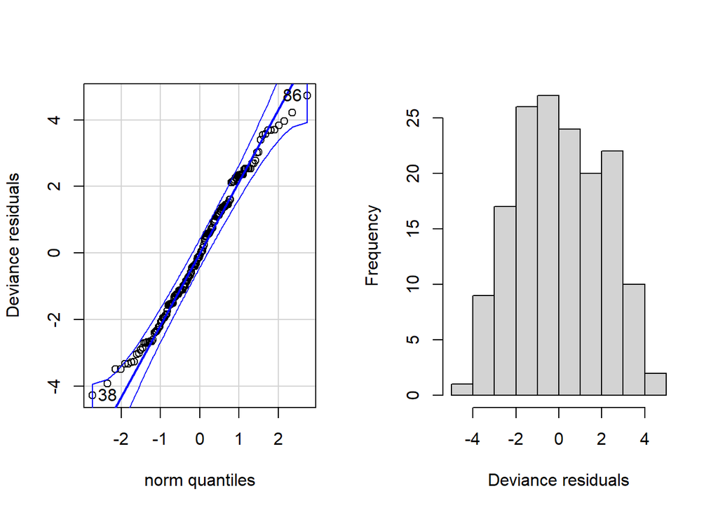

```r
hist(res,10,xlab="Deviance residuals", main="")
```

3. 3 pts - Calculate the estimated dispersion parameter for this model. Is this an overdispersed model?

```r
# Calculate overdispersion parameter
model1$deviance/model1$df.res
```

```
## [1] 4.051539
```

The estimated dispersion parameter is larger than 2, so overdispersion is a concern for this model.

# Question 4: Fitting the full model- 23 pts

Fit a logistic regression model using *Staying* as the response variable with *Age.Group*, *Gender*, *Tenure*, *Num.Of.Products*, and *Is.Active.Member* as the predictors and logit as the link function. Call it **model2**. Ensure to include the weights parameter for specifying the number of trials.Note that Age.Group, Gender, Num.Of.Products, and Is.Active.Member should be treated as categorical variables.

```r
# Create model2
model2 = glm(Staying ~ Age.Group + Gender + Tenure
                         + Num.Of.Products + Is.Active.Member,
                         data=rawdata,family='binomial', weights=Employees)
summary(model2)
```

```
##
## Call:
## glm(formula = Staying ~ Age.Group + Gender + Tenure + Num.Of.Products +
##     Is.Active.Member, family = "binomial", data = rawdata, weights = Employees)
##
## Deviance Residuals:
##      Min        1Q    Median        3Q       Max
## -3.10929  -0.76949  -0.07324   0.74079   3.06551
##
## Coefficients:
##                    Estimate Std. Error z value Pr(>|z|)
## (Intercept)       -0.109572   0.282617  -0.388    0.698
## Age.Group3         0.384480   0.267984   1.435    0.151
## Age.Group4         1.734115   0.270384   6.414 1.42e-10 ***
## Age.Group5         2.955578   0.337727   8.751  < 2e-16 ***
## Gender1           -0.572069   0.093776  -6.100 1.06e-09 ***
## Tenure            -0.003319   0.016569  -0.200    0.841
## Num.Of.Products2  -1.410946   0.112000 -12.598  < 2e-16 ***
## Is.Active.Member1 -0.850280   0.095829  -8.873  < 2e-16 ***
## ---
## Signif. codes:  0 '***' 0.001 '**' 0.01 '*' 0.05 '.' 0.1 ' ' 1
##
## (Dispersion parameter for binomial family taken to be 1)
##
##     Null deviance: 981.04  on 157  degrees of freedom
## Residual deviance: 162.35  on 150  degrees of freedom
## AIC: 599.07
##
## Number of Fisher Scoring iterations: 4
```

1. 3 pts - Write down the equation for the probability of staying.

Let $x_{Age.Group3}= x_1, x_{Age.Group4}=x_2, x_{Age.Group5}=x_3, x_{Gender1}=x_4, x_{Tenure}=x_5, x_{Num.Of.Products2}=x_6, x_{Is.Active.Member1}=x_7$. The probability of staying can be defined as:

$$p_{staying} = \frac{e^{\beta_0+\beta_1*x_{1}+\beta_2*x_{2}+\beta_3*x_{3}+\beta_4*x_{4}+\beta_5*x_{5}+\beta_6*x_{6}+\beta_7*x_{7}}}{1+e^{\beta_0+\beta_1*x_{1}+\beta_2*x_{2}+\beta_3*x_{3}+\beta_4*x_{4}+\beta_5*x_{5}+\beta_6*x_{6}+\beta_7*x_{7}}}$$
Substituting the model parameters with the estimates, we get:

$$\hat{p_{staying}} = \frac{e^{-0.1095+0.384*x_{1}+1.734*x_{2}+2.955*x_{3}-0.572*x_{4}-0.003*x_{5}-1.410*x_{6}-0.8502*x_{7}}}{1+e^{-0.1095+0.384*x_{1}+1.734*x_{2}+2.955*x_{3}-0.572*x_{4}-0.003*x_{5}-1.410*x_{6}-0.8502*x_{7}}}$$

2. 3 pts - Provide a meaningful interpretation for the estimated coefficients of *Tenure* and *Is.Active.Member1* with respect to the odds of staying.

*Tenure:*

- A one unit increase in *Tenure* decreases the odds of an employee staying with the company by 0.3% holding all other predictors constant. $1 - e^{-0.003} = 0.003$
- A one unit increase in *Tenure* changes the odds of an employee staying with the company by a factor of 0.997 holding all other predictors constant. $e^{-0.003} = 0.997$

*Is.Active.Member1:*

- The odds of staying for an employee who is an active member(*Is.Active.Member1*) is 57.26% lower than that of an employee who is not an active member (*Is.Active.Member0*) holding all other predictors constant. $1-e^{-0.8502} = 0.5726$
- The odds of staying for an employee who is an active member(*Is.Active.Member1*) change by a factor of 0.4273 relative to an employee ho is not an active member (*Is.Active.Member0*) holding all other predictors constant. $e^{-0.8502} = 0.4273$

*Note: Only one correct interpretation with respect to the odds of staying is needed for credit. The above are different examples of possible answers.*

3. 3 pts - Is *Is.Active.Member1* statistically significant given the other variables in model2 at the 0.01 significance level?

*Is.Active.Member1* has a two-sided p-value that is less than 2e-16. Since this p-value is so small, *Is.Active.Member1* is significant given the other variables in the model.

4. 10 pts - Has your goodness of fit been affected? Follow the instructions to repeat the tests, plots, and dispersion parameter calculation you performed in Question 3 with model2.

(d-1) Perform goodness-of-fit hypothesis tests using both Deviance and Pearson residuals. What do you conclude?

First, let’s check algorithmically whether the model seems to be a good fit by performing a goodness of fit test using Pearson and Deviance residuals.

```r
# Deviance residuals test
cat("Deviance residuals test p-value:",
1-pchisq(model2$deviance, model2$df.residual), end="\n")
```

```
## Deviance residuals test p-value: 0.2319118
```

```r
# Pearson residuals test
pResid <- resid(model2, type = "pearson")
cat("Pearson residuals test p-value:",
1-pchisq(sum(pResid^2), model2$df.residual))
```

```
## Pearson residuals test p-value: 0.3912174
```

The p-values of both tests for goodness of fit are large, suggesting that the model might be a good fit.

Next, let’s use visual analytics for assessing the model assumptions.

(d-2) Evaluate the linearity assumption of **model2** by plotting the log-odds of Staying vs. **Tenure**. What do you conclude?

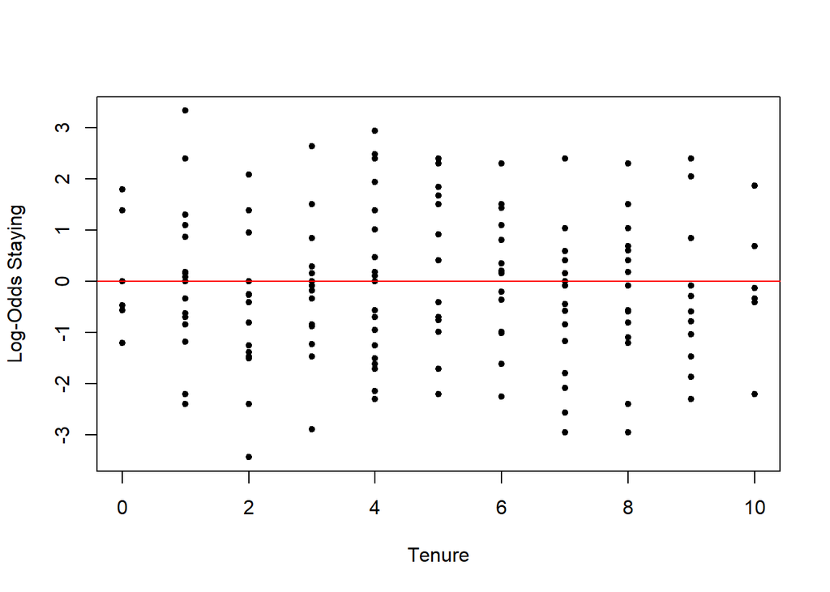

```r
# Plot of the log-odds of Staying against Tenure
col_name = names(rawdata[3])
plot(rawdata[,3],log(rawdata$Staying/(1-rawdata$Staying)),
    xlab= col_name, ylab = "Log-Odds Staying",
    pch=20)
abline(0,0, col="red")
```

We can assess the linearity assumption by plotting the log-odds of Staying against the *Tenure*. There isn’t any evident non-linear pattern in the plot suggesting that the linearity assumption does not hold, but based on the plot the marginal relationship between the log-odds of Staying and Tenure is very weak.

(d-3) Evaluate whether the deviance residuals are normally distributed by producing a QQ plot and histogram of the deviance residuals. What do you conclude?

```r
# Store the deviance residuals
res2 = resid(model2,type="deviance")

par(mfrow=c(1,2))
qqPlot(res2, ylab="Std residuals")
```

```
## [1] 19 14
```

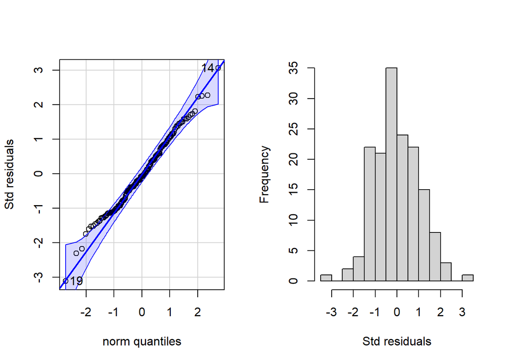

```r
hist(res2,10,xlab="Std residuals", main="")
```

We can evaluate the QQ plot and the histogram of the deviance residuals. When the model fits well, the deviance residuals should be approximately normal. The qqplot shows that the majority of the deviance residuals fall inside of the 95% confidence interval. Based on these plots, model2 seems to be a good fit for the data.

Finally, let’s calculate the dispersion parameter.

(d-3) Calculate the estimated dispersion parameter for this model. Is this an overdispersed model?

```r
model2$deviance/model2$df.res
```

```
## [1] 1.08233
```

The dispersion parameter is now smaller than 2. There is no overdispersion anymore.

*Note: The above are different examples of possible answers. Interpretation of plots can be subjective. Primarily, we’re looking for sound justification and logical reasoning.*

5. 4 pts - Overall, would you say model2 is a good-fitting model? If so, why? If not, what would you suggest to improve the fit and why? Note, we are not asking you to spend hours finding the best possible model but to offer plausible suggestions along with your reasoning.

From the plots and tests in the previous question, the goodness of fit appears to have improved with the addition of new variables. Overall, model2 appears to be a good-fitting model.

One possibility to improve the fit is to change the link function. Changing it from logit to cloglog (complementary log-log) reduces the deviance slightly (from 162.35 to 155.73).

Some other ideas for improving the fit are transforming the data, removing influential points from the data, and considering other predicting variables.

```r
# Create model3
model3 = glm(Staying ~ Age.Group + Gender + Tenure + Num.Of.Products + Is.Active.Member,
data=rawdata,family=binomial(link="cloglog"), weights=Employees)
dp <-sum(residuals(model3,type="deviance")^2)/model3$df.res
summary(model3, dispersion=dp)
```

```
##
## Call:
## glm(formula = Staying ~ Age.Group + Gender + Tenure + Num.Of.Products +
##     Is.Active.Member, family = binomial(link = "cloglog"), data = rawdata,
##     weights = Employees)
##
## Deviance Residuals:
##     Min       1Q   Median       3Q      Max
## -2.9058  -0.7206  -0.0693   0.6660   2.8439
##
## Coefficients:
##                    Estimate Std. Error z value Pr(>|z|)
## (Intercept)       -0.537499   0.232832  -2.309    0.021 *
## Age.Group3         0.303000   0.226678   1.337    0.181
## Age.Group4         1.260872   0.225036   5.603 2.11e-08 ***
## Age.Group5         1.837731   0.239075   7.687 1.51e-14 ***
## Gender1           -0.359035   0.063413  -5.662 1.50e-08 ***
## Tenure            -0.006161   0.011175  -0.551    0.581
## Num.Of.Products2  -1.089106   0.092190 -11.814  < 2e-16 ***
## Is.Active.Member1 -0.604176   0.066501  -9.085  < 2e-16 ***
## ---
## Signif. codes:  0 '***' 0.001 '**' 0.01 '*' 0.05 '.' 0.1 ' ' 1
##
## (Dispersion parameter for binomial family taken to be 1.038216)
##
##     Null deviance: 981.04  on 157  degrees of freedom
## Residual deviance: 155.73  on 150  degrees of freedom
## AIC: 592.45
##
## Number of Fisher Scoring iterations: 5
```

# Question 5: Prediction - 9 pts

Suppose there is an employee with the following characteristics:

1. **Age.Group**: 2
2. **Gender**: 0
3. **Tenure**: 2
4. **Num.Of.Products**: 2
5. **Is.Active.Member**: 1
1. 3 pts - Predict their probability of staying using model1.

```r
# Create the new employee
newemployee_categorical = data.frame(Age.Group='2',
                                     Gender='0',
                                     Tenure=2,
                                     Num.Of.Products='2',
                                     Is.Active.Member='1')
predict(model1, newemployee_categorical, type="response")
```

```
##         1
## 0.1997319
```

Using model1, given the above characteristics of an employee the probability of staying is predicted to be equal to 0.1997319 (~20%).

2. 3 pts - Predict their probability of staying using model2.

```r
predict(model2,newemployee_categorical,type="response")
```

```
##          1
## 0.08490958
```

Using model2, given the above characteristics of an employee the probability of staying is predicted to be equal to 0.08490958(~8%).

3. 3 pts - Comment on how your predictions compare. i.e. which model is more reliable based on the analysis?

When Age.Group, Gender, Tenure, and Is.Active.Member are taken into consideration, the employee’s predicted probability of staying at the company decreases by about 0.11. Based on the goodness of fit tests, model2 seems to be much more reliable than model1, and it might be possible that model1 is overestimating the probability that this employee will stay with the company. However, we might need to split our data set into training and testing sets and calculate prediction accuracy measurements in order to further evaluate the prediction accuracy of the models.